# Thefts are more common in San Francisco in weekends and in evening

Larionova Anna

30.11.2015

## Data preparation

### Switch on libraries

```r
setwd("E:/Personal/Repos/DS_at_scale/assignment6")
library(chron)
```

```r
library(ggplot2)
```

### Take data

```r
sf_crime <- read.csv("sanfrancisco_incidents_summer_2014.csv")
```

### Mark out day time intervals

Transform time series to categorical data by spliting time on four equal intervals, each interval is assigned to day time category: morning, day, evening and night as follows below

```r
sf_crime$Time1 <- chron(times. = paste0(as.character(sf_crime$Time), ":00", sep=""))
sf_crime$DayTime <- ifelse(sf_crime$Time1 >= chron(times. = "00:00:00") & sf_crime$Time1 < chron(times. = "06:00:00"), "night", "")
sf_crime$DayTime <- ifelse(sf_crime$Time1 > chron(times. = "18:00:00") & sf_crime$Time1 <= chron(times. = "23:59:00"), "evening", sf_crime$DayTime)
sf_crime$DayTime <- ifelse(sf_crime$Time1 > chron(times. = "12:00:00") & sf_crime$Time1 <= chron(times. = "18:00:00"), "day", sf_crime$DayTime)
sf_crime$DayTime <- ifelse(sf_crime$Time1 >= chron(times. = "06:00:00") & sf_crime$Time1 <= chron(times. = "12:00:00"), "morning", sf_crime$DayTime)
sf_crime$DayTime <- as.factor(sf_crime$DayTime)
```

## Graphics

The first figure shows crime frequency by category for particular time of the day (morning, day, evening and night). Despite the common belief that most of the crimes occur at night the figure shows that in general most crimes occures in San Francisco between 12 - 18 hours (day), then comes evening, morning and the lats in night. However thefts occur a little more frequent in evening. This can be explained. Criminals are humans, they need a time to rest (and sleep), at night most people are a sleep, so crimes like assault, theft and some others are more difficult to commit because most of the victims are at home.

```r
crimes_daytime <- aggregate(sf_crime$Descript ~ sf_crime$Category + sf_crime$DayTime, data = sf_crime, length)
names(crimes_daytime) <- c("Category", "DayTime", "Crime_frequency")
head(crimes_daytime[order(-crimes_daytime$Crime_frequency),], 15)
```

```
##           Category DayTime Crime_frequency
## 44   LARCENY/THEFT evening            3486
## 14   LARCENY/THEFT     day            3253
## 75   LARCENY/THEFT morning            1781
## 19  OTHER OFFENSES     day            1164
## 18    NON-CRIMINAL     day            1081
## 49  OTHER OFFENSES evening             985
## 106  LARCENY/THEFT   night             946
## 33         ASSAULT evening             881
## 79    NON-CRIMINAL morning             858
## 2          ASSAULT     day             848
## 80  OTHER OFFENSES morning             839
## 59   VEHICLE THEFT evening             811
## 48    NON-CRIMINAL evening             724
## 30        WARRANTS     day             668
## 63         ASSAULT morning             584
```

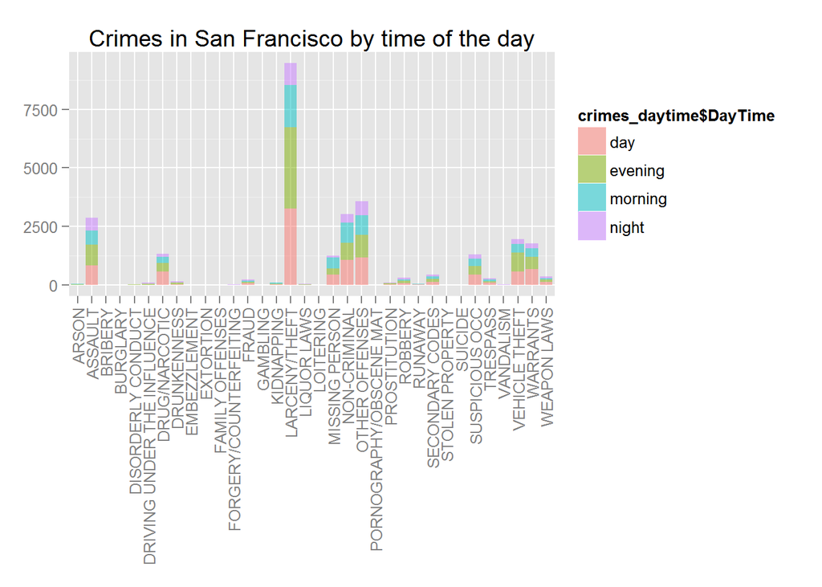

```r
g1 <- ggplot(crimes_daytime, aes(x = crimes_daytime$Category, y = crimes_daytime$Crime_frequency, fill = crimes_daytime$DayTime)) + geom_histogram(binwidth = .5, alpha = .5, stat = "identity") + theme(axis.title = element_blank(), legend.position = "right", axis.text.x = element_text(angle = 90, hjust = 1, vjust = 0.5)) + ggtitle("Crimes in San Francisco by time of the day")
g1
```

The second figure shows number of crimes depending on the day of the week. It is clear to see that most crimes occur on Friday and weekends. Tuesday and Thursday are the least “criminal” days of the week.

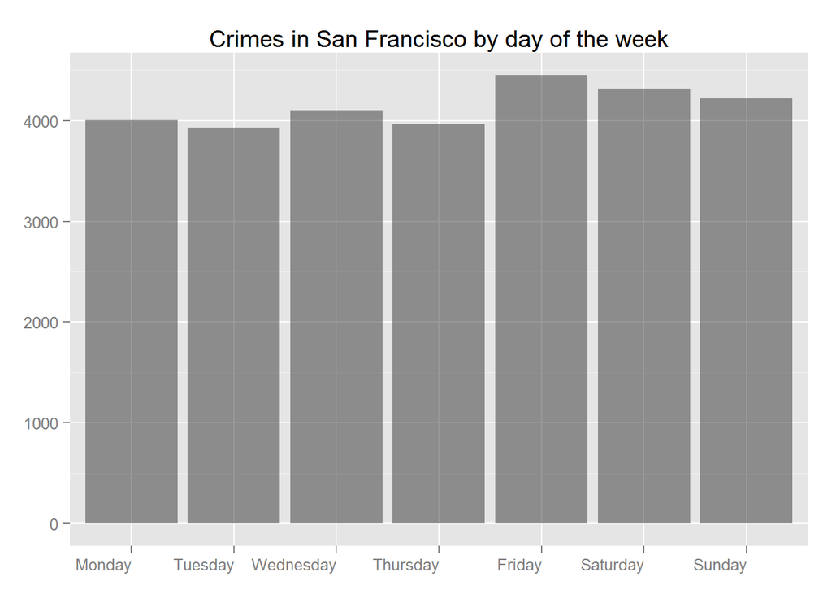

```r
crime_by_weekday <- as.data.frame(summary(sf_crime$DayOfWeek))
crime_by_weekday$WeekDay <- rownames(crime_by_weekday)
names(crime_by_weekday) <- c("Crime_frequency", "WeekDay")
crime_by_weekday <- crime_by_weekday[c(2, 6, 7, 5, 1, 3, 4),c(2, 1)]
rownames(crime_by_weekday) <- NULL
crime_by_weekday$WeekDay <- factor(crime_by_weekday$WeekDay, levels = c("Monday", "Tuesday", "Wednesday", "Thursday", "Friday", "Saturday", "Sunday"))
g2<- ggplot(crime_by_weekday, aes(x = factor(crime_by_weekday$WeekDay), y = crime_by_weekday$Crime_frequency)) + geom_histogram(binwidth = .5, alpha = .5, stat = "identity") + theme(axis.title = element_blank(), legend.position = "none", axis.text.x = element_text(angle = 0, hjust = 1, vjust = 0.5)) + ggtitle("Crimes in San Francisco by day of the week")
g2
```

The third figure shows particular crimes by week day dependency. Just like in prevous graphcs we can see that most of the crimes occur on Friday, Saturday and Sunday. The most frequent crimes that occur during the week are assault, drug/narkotic, larceny/theft, vehicle theft, etc. Friday is the end of working week, people are likely to receive the paycheck and start shopping and entertaining, so the have money and things to steal, they end working earlier so more assaults can be committed in the same time interval. The weekends are the same: people likely to go out for entertainment and money spending.

```r
crimes_weekday <- aggregate(sf_crime$Descript ~ sf_crime$Category + sf_crime$DayOfWeek, data = sf_crime, length)
names(crimes_weekday) <- c("Category", "WeekDay", "Crime_frequency")
crimes_weekday$WeekDay <- factor(crimes_weekday$WeekDay, levels = c("Monday", "Tuesday", "Wednesday", "Thursday", "Friday", "Saturday", "Sunday"))
head(crimes_weekday[order(-crimes_weekday$Crime_frequency),], 15)
```

```
##           Category   WeekDay Crime_frequency
## 70   LARCENY/THEFT  Saturday            1583
## 97   LARCENY/THEFT    Sunday            1505
## 13   LARCENY/THEFT    Friday            1445
## 158  LARCENY/THEFT   Tuesday            1237
## 127  LARCENY/THEFT  Thursday            1235
## 41   LARCENY/THEFT    Monday            1233
## 189  LARCENY/THEFT Wednesday            1228
## 17  OTHER OFFENSES    Friday             547
## 163 OTHER OFFENSES   Tuesday             536
## 132 OTHER OFFENSES  Thursday             526
## 193 OTHER OFFENSES Wednesday             522
## 74  OTHER OFFENSES  Saturday             507
## 46  OTHER OFFENSES    Monday             496
## 16    NON-CRIMINAL    Friday             468
## 87         ASSAULT    Sunday             462
```

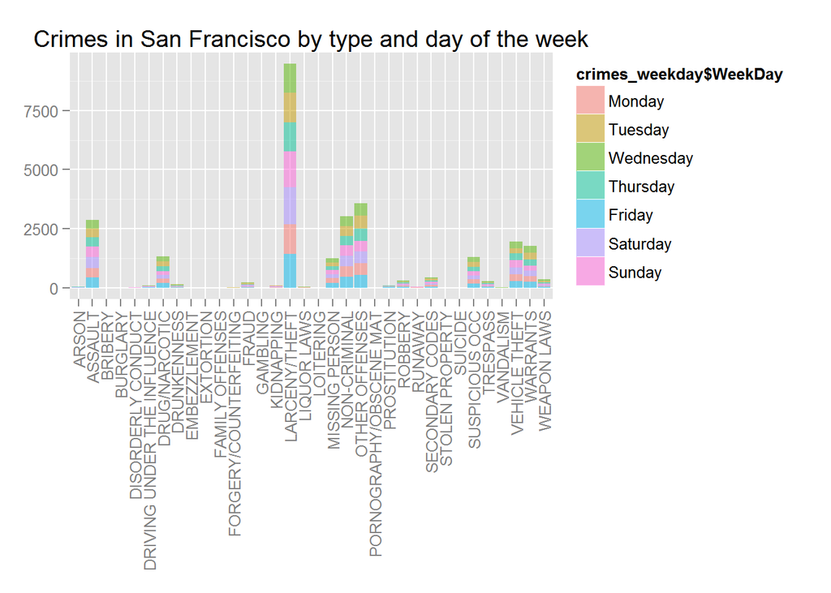

```r
g3 <- ggplot(crimes_weekday, aes(x = crimes_weekday$Category, y = crimes_weekday$Crime_frequency, fill = crimes_weekday$WeekDay)) + geom_histogram(binwidth = .5, alpha = .5, stat = "identity") + theme(axis.title = element_blank(), legend.position = "right", axis.text.x = element_text(angle = 90, hjust = 1, vjust = 0.5)) + ggtitle("Crimes in San Francisco by type and day of the week")
g3
```

## Conclution

The most of crimes are committed during day or evening on Friday and weekends. The most safe time is night and workdays.